| title: EnsembleLearning with R |
| --- |
| output: html_document |

# Loan prediction challange:

The challange is to model loan applications and predict if they will go bad or not.

In the datasets, the first row contains the labels of the attributes. In the training data set, there is an additional final column (named Loan Status) which has the information on whether the loans will turn bad (0) or not (1).

Our task here is to split the given training dataset into train and test (i.e., hold-out sample) and build a model on the train dataset and test the model predicted results against the Loan Status column in the test data set.

Labels of attributes is shown below.

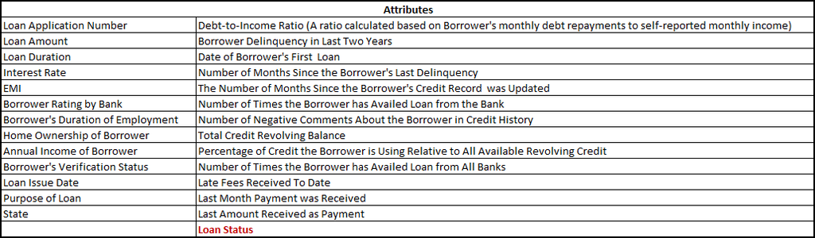

## Setting up the working directory in R

## Load required R packages for this exercise

```r
setwd("D:\\Kaggle\\Yodlee")

library(tree)
library(dplyr)
library(adabag)
library(glm2)
```

### Read and store the given training data set in R

Since we have ‘percentage symbols’ and ‘months’ attached with the values in EMI column and Loan Duration column it is desirable to remove them and convert the character type varibles into factor variables. ‘%>%’ is an operator used in dplyr package.

# Feature Engineering

We cannot use State as one the predictors in our model hence it is decided to compute and use the frequency of loan applications per State. Likewise the frequency of loans are computed by bank rating and used.

# Missing values

Missing values are noted in the following columns.

- No_of_Loans (Number of time the borrower has availed the loan from the bank)
- Credit_Balance (Total Credit Revolving balance)
- Percentage_Used_Credit (Percentage of Credit the Borrower is Using Relative to All Available Revolving Credit)
- No_of_Loans_Other_Banks (Number of Times the Borrower has Availed Loan from All Banks)

### Exclude the variables like Loan_No (Loan Application Number) and other columns with date values

# Cross validation samples - Split the data set into two portions (70% - Train; 30% - Test)

# Logistic Regression Model

First two GLM models were studied and based on the results GLM3 (glm.fit3) is finalised.

```
##
## Call:
## glm(formula = Loan_Status ~ EMI + Late_Fees + Last_Amount + loans_by_state,
##     family = binomial, data = loan_train)
##
## Deviance Residuals:
##     Min       1Q   Median       3Q      Max
## -6.2791   0.0014   0.2899   0.6666   3.5679
##
## Coefficients:
##                  Estimate Std. Error z value Pr(>|z|)
## (Intercept)     1.642e+00  5.201e-02  31.572  < 2e-16 ***
## EMI            -2.324e-04  1.197e-05 -19.414  < 2e-16 ***
## Late_Fees      -3.370e-03  2.507e-04 -13.442  < 2e-16 ***
## Last_Amount     1.561e-04  7.755e-06  20.126  < 2e-16 ***
## loans_by_state -5.245e-05  1.770e-05  -2.964  0.00303 **
## ---
## Signif. codes:  0 '***' 0.001 '**' 0.01 '*' 0.05 '.' 0.1 ' ' 1
##
## (Dispersion parameter for binomial family taken to be 1)
##
##     Null deviance: 13826  on 16799  degrees of freedom
## Residual deviance: 11110  on 16795  degrees of freedom
## AIC: 11120
##
## Number of Fisher Scoring iterations: 9
```

## GLM model was fit for test observations

# Confusion matrix and Model Accuracy

```
##         loan_Status_test
## glm.pred    0    1
##        0   62   72
##        1 1029 6037
```

```
## [1] 0.8470833
```

# Decision Tree Model

## Decision tree is built using tree package in R

```
##
## Classification tree:
## tree(formula = Loan_Status ~ ., data = loan_train)
## Variables actually used in tree construction:
## [1] "Last_Amount"   "Loan_Duration" "Late_Fees"     "Interest_Rate"
## Number of terminal nodes:  6
## Residual mean deviance:  0.5655 = 9491 / 16780
## Misclassification error rate: 0.1059 = 1778 / 16788
```

Decision Tree:

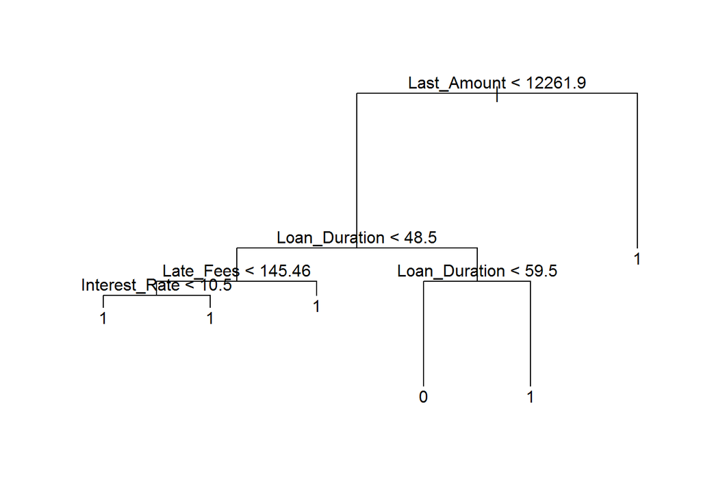

## Decision tree model is fit fot test observations and computed Confusion matrix.

```
##          loan_Status_test
## tree.pred    0    1
##         0  335   68
##         1  756 6041
```

```
## [1] 0.8855556
```

# Tree Pruning using Cross Validation method

### Prune the tree to select number of trees to end up with.

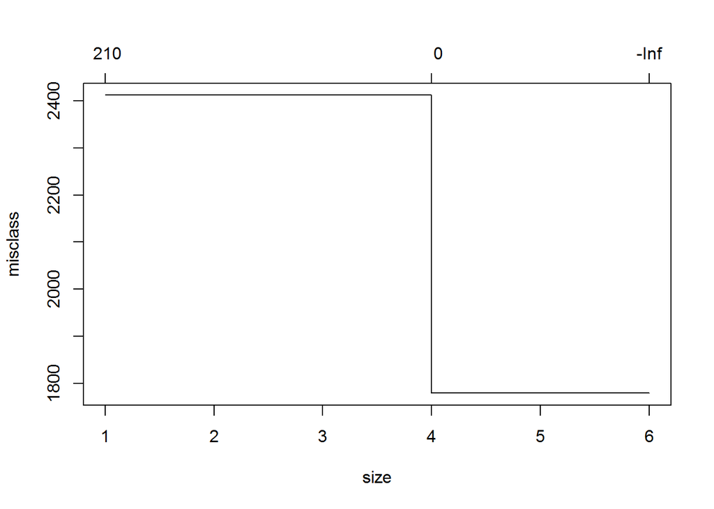

## Application of Repruned tree

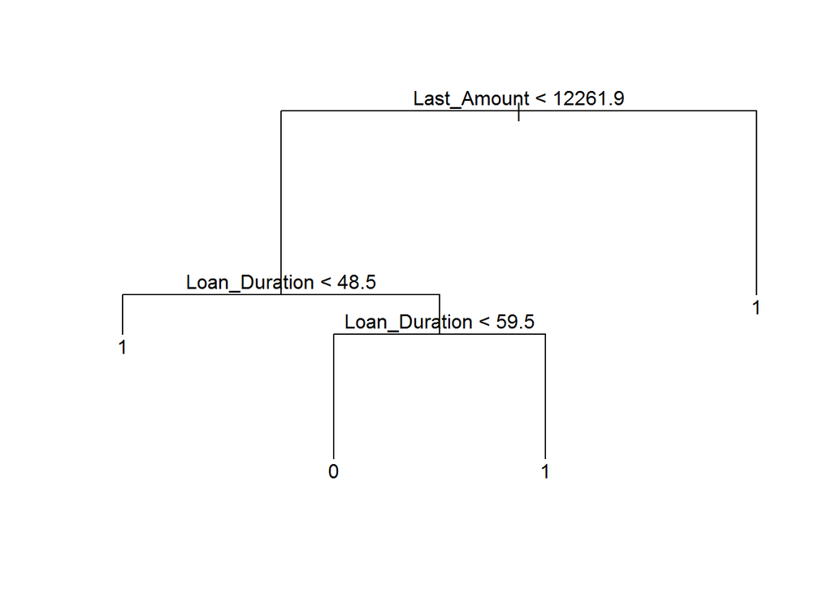

```
##          loan_Status_test
## tree.pred    0    1
##         0  335   68
##         1  756 6041
```

```
## [1] 0.8855556
```

# ADABOOST.M1 Algorithm

[output not shown]

[output cut: 151 more lines]

[output not shown]

```
##   [1] 0.997343394 0.662805515 0.498419144 0.318935157 0.313220523
##   [6] 0.309432875 0.263115337 0.216799296 0.204354741 0.212483411
##  [11] 0.219346518 0.153511397 0.140857101 0.154611027 0.137422235
##  [16] 0.092337512 0.110334353 0.089004496 0.126749405 0.151621238
##  [21] 0.087366563 0.116284103 0.053679844 0.075040912 0.060072889
##  [26] 0.066208173 0.049564478 0.085467024 0.045136327 0.044583957
##  [31] 0.005193925 0.002612367 0.059787372 0.078752990 0.099646231
##  [36] 0.040909022 0.059277159 0.099194773 0.038336781 0.058484085
##  [41] 0.053463350 0.066792348 0.038094402 0.021848262 0.029486298
##  [46] 0.049693170 0.007357189 0.032444969 0.022764077 0.021966101
##  [51] 0.066933337 0.072118731 0.047155620 0.035918676 0.000614611
##  [56] 0.017379091 0.022392754 0.055144097 0.034406441 0.025508795
##  [61] 0.027265888 0.080904135 0.026337747 0.010464666 0.017398868
##  [66] 0.057620205 0.051009160 0.063505575 0.043339513 0.022679070
##  [71] 0.009247068 0.006276462 0.044093071 0.028729162 0.017570037
##  [76] 0.007681528 0.026768829 0.080728170 0.040160595 0.019109344
##  [81] 0.023630225 0.029069256 0.007031071 0.015103014 0.042608746
##  [86] 0.002336451 0.041151311 0.021971276 0.024145205 0.011073581
##  [91] 0.008139204 0.033682992 0.017921543 0.008761952 0.010761719
##  [96] 0.005833927 0.029838029 0.069940207 0.023403170 0.011507790
```